# 30 min Introduction to Statistics with R

(複習) EDA 的基礎：

- data wrangling
- visualization
- statistics

## 學習方法

- 統計學教科書概念學習 + 習題的 R 實作。
- 多利用說明文件瞭解相關函數內容。(e.g., `?sd`, `example(sd)`)

```r
str(hedges)
```

```
'data.frame':   60 obs. of  3 variables:
 $ CASE  : int  1 2 3 4 5 6 7 8 9 10 ...
 $ HEDGES: int  17 17 17 17 16 13 14 16 12 11 ...
 $ SEX   : Factor w/ 2 levels "F","M": 1 1 1 1 1 1 1 1 1 1 ...
```

## 探索一個變數

### 量化數據

敘述統計量：mean、sd、median

```r
sd(HEDGES)
```

```
[1] 4.379556
```

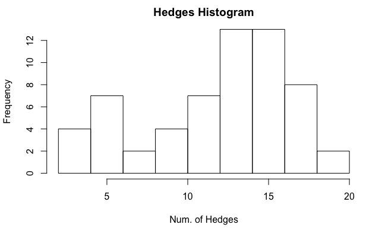

```r
# Graphic exploration
# histogram
hist(HEDGES, main = "Hedges Histogram", xlab = "Num. of Hedges")
```

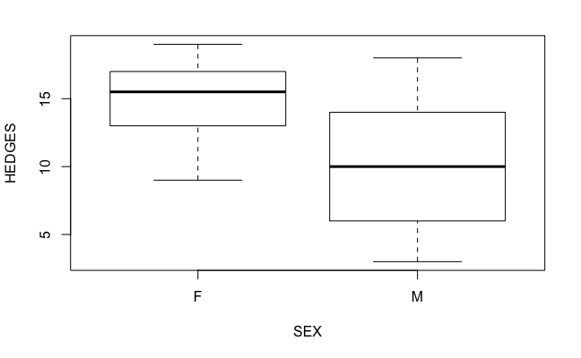

```r
# scatter plot
plot(HEDGES ~ SEX, data = hedges)
```

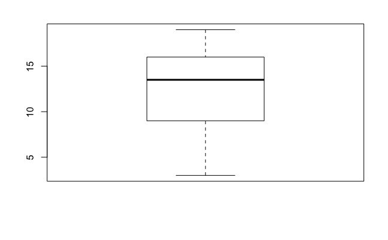

```r
# boxplot
boxplot(HEDGES)
```

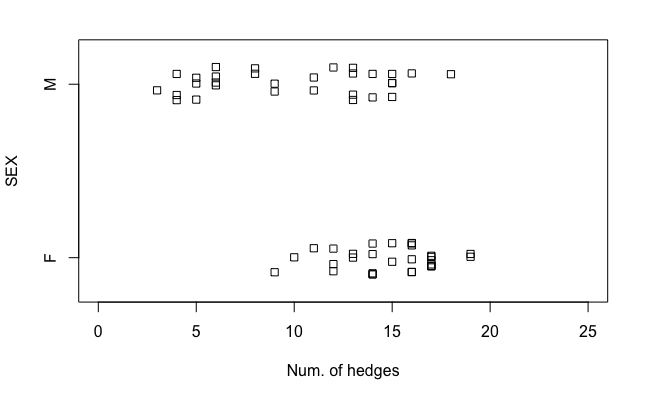

```r
stripchart(HEDGES~SEX, method="jitter", xlim=c(0, 25),xlab="Num. of hedges", ylab="SEX")
#stripchart(HEDGES~SEX, method="stack", xlim=c(0, 25),xlab="Num. of hedges", ylab="SEX")
par(mfrow=c(1,2))
```

```r
hist(HEDGES[SEX=="M"], xlim=c(0, 25), ylim=c(0, 10), ylab="Frequency", main="")
hist(HEDGES[SEX=="F"], xlim=c(0, 25), ylim=c(0, 10), ylab="Frequency", main="")
```

[figure not shown]

```r
par(mfrow=c(1, 1))
```

```r
# Do make use of dplyr
group_by(hedges, SEX) %>%
  summarise(平均不正面用語 = mean(HEDGES))
```

| SEX | 平均不正面用語 |
| --- | --- |
| F | 14.833333 |
| M | 9.866667 |

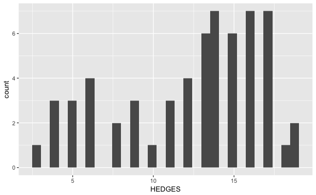

```r
### ggplot2
# histogram
ggplot(data = hedges) +
  geom_histogram(aes(x = HEDGES))
```

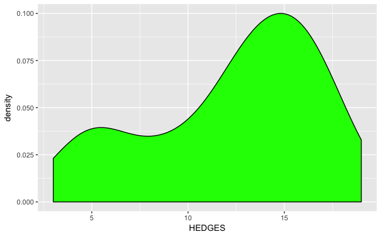

```r
# density plot
ggplot(data = hedges) +
  geom_density(aes(x = HEDGES), fill = "green")
```

### 質化數據

分佈表格：table 眾數：table + sort

```r
table(hedges$HEDGES, hedges$SEX)
```

```
     F M
  3  0 1
  4  0 3
  5  0 3
  6  0 4
  8  0 2
  9  1 2
  10 1 0
  11 1 2
  12 3 1
  13 2 4
  14 5 2
  15 2 4
  16 6 1
  17 7 0
  18 0 1
  19 2 0
```

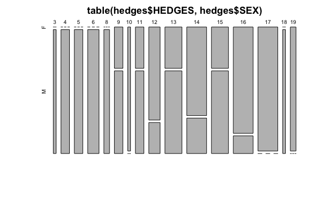

```r
plot(table(hedges$HEDGES, hedges$SEX))
```

```r
dists<-prop.table(table(HEDGES, SEX), margin=2); dists
```

```
      SEX
HEDGES          F          M
    3  0.00000000 0.03333333
    4  0.00000000 0.10000000
    5  0.00000000 0.10000000
    6  0.00000000 0.13333333
    8  0.00000000 0.06666667
    9  0.03333333 0.06666667
    10 0.03333333 0.00000000
    11 0.03333333 0.06666667
    12 0.10000000 0.03333333
    13 0.06666667 0.13333333
    14 0.16666667 0.06666667
    15 0.06666667 0.13333333
    16 0.20000000 0.03333333
    17 0.23333333 0.00000000
    18 0.00000000 0.03333333
    19 0.06666667 0.00000000
```

## 探索(兩個)變數之間的關係

- `ftable`：質 v.s. 質
- `bar chart` `box plot`：質 v.s. 量
- `scatter plot`： 量 v.s. 量

```r
(FT <- ftable(Titanic, row.vars = 1:3))
```

[output not shown]

(複習 RStudio cheat sheet) 繪圖之前的整理資料 `dplyr`, Regular Expression 相關函式/ `stringr`

(複習 RStudio cheat sheet) `ggplot2`

- 先把資料整理成 data.frame 送至 `ggplot()` 產生畫布
- 各種繪圖工具利用 aes (外觀設定：管理座標軸、顏色變化) 、geom (幾何圖形： 產生點、線、三角等圖形)，來定位欄位和對應的圖的元素: x座標、y座標、顏色、分群
- 再一層一層的疊上繪圖要素: 點、線、各種文字與標題說明； 改變繪圖座標的 coord 、佈景主題 theme 以及控制圖形輸出的 facet 。

進階做圖：美化 `ggthemes` 與互動

## 統計檢定

```r
shapiro.test(hedges$HEDGES)
```

```
    Shapiro-Wilk normality test

data:  hedges$HEDGES
W = 0.9168, p-value = 0.0005716
```

```r
# NOT normally distributed. Since of the p-value is > 0.05,
# the dataset is normally distributed)
```

```r
## Independent var = categorical
## Dependent var.  = categorical     >> chi-square
##                 = not categorical >> t-test
## Dependent variable :  HEDGE (non-categorical)
## Independent variable: SEX (categorical)
#H0: The distribution of the dependent variable HEDGES does not differ depending
#on the levels of the independent variable SEX; D = 0.
#H1: The distribution of the dependent variable HEDGES differs depending on
#the levels of the independent variable SEX; D > 0.
ks.test(HEDGES[SEX=="M"], HEDGES[SEX=="F"])
```

```
cannot compute exact p-value with ties
```

```
    Two-sample Kolmogorov-Smirnov test

data:  HEDGES[SEX == "M"] and HEDGES[SEX == "F"]
D = 0.46667, p-value = 0.002908
alternative hypothesis: two-sided
```

```r
# t-test
t.test(HEDGES~SEX, hedges)
```

```
    Welch Two Sample t-test

data:  HEDGES by SEX
t = 5.3083, df = 45.594, p-value = 3.171e-06
alternative hypothesis: true difference in means is not equal to 0
95 percent confidence interval:
 3.082848 6.850485
sample estimates:
mean in group F mean in group M
      14.833333        9.866667
```

```r
# non-parametric corelation
cor.test(diamonds$price, diamonds$carat, method= "spearman")
```

```
Cannot compute exact p-value with ties
```

```
    Spearman's rank correlation rho

data:  diamonds$price and diamonds$carat
S = 9.7086e+11, p-value < 2.2e-16
alternative hypothesis: true rho is not equal to 0
sample estimates:
      rho
0.9628828
```

## 迴歸分析

流浪汪星人

- `computerR`: 各縣市平均每100個家庭的電腦數目
- `graduate`: 各縣市研究所畢業者人數

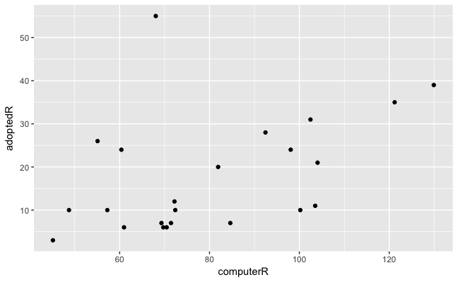

```r
require(dplyr)
require(ggplot2)
#https://www.dropbox.com/s/t8doe35f3o2we2m/dogs.txt?dl=0
# big5 data 用 file - reopen with encoding - save with encoding
dogs <- read.table("../../../data/txt/dogs.txt", header = T, fileEncoding="utf8")
qplot(computerR, adoptedR, data=dogs)
```

- 迴歸係數計算推論

```r
lm.model <- lm(adoptedR~computerR, data=dogs, x =TRUE)
summary(lm.model)
```

```
Call:
lm(formula = adoptedR ~ computerR, data = dogs, x = TRUE)

Residuals:
    Min      1Q  Median      3Q     Max
-12.950  -8.263  -2.939   6.845  40.338

Coefficients:
            Estimate Std. Error t value Pr(>|t|)
(Intercept)  -2.8601     9.4447  -0.303   0.7650
computerR     0.2576     0.1137   2.264   0.0343 *
---
Signif. codes:  0 ‘***’ 0.001 ‘**’ 0.01 ‘*’ 0.05 ‘.’ 0.1 ‘ ’ 1

Residual standard error: 12.18 on 21 degrees of freedom
Multiple R-squared:  0.1963,    Adjusted R-squared:  0.158
F-statistic: 5.128 on 1 and 21 DF,  p-value: 0.03425
```

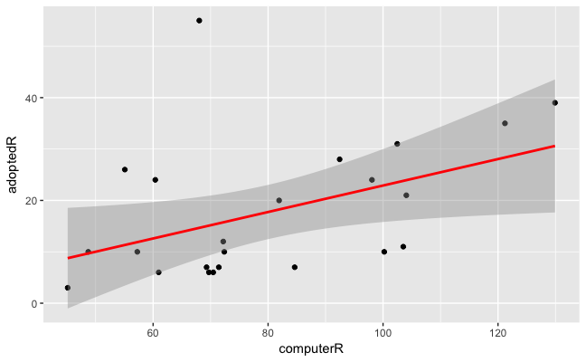

```r
#plot(computerR~adoptedR, data=dogs)
ggplot(dogs, aes(x = computerR, y = adoptedR)) +
  geom_point() +
  stat_smooth(method = "lm", col = "red")
```

- 簡單線性迴歸的 ANOVA 表格

```r
anova(lm.model)
```

```
Analysis of Variance Table

Response: adoptedR
          Df  Sum Sq Mean Sq F value  Pr(>F)
computerR  1  760.77  760.77  5.1277 0.03425 *
Residuals 21 3115.67  148.37
---
Signif. codes:  0 ‘***’ 0.001 ‘**’ 0.01 ‘*’ 0.05 ‘.’ 0.1 ‘ ’ 1
```

- 殘差分析 (Residuals analysis)

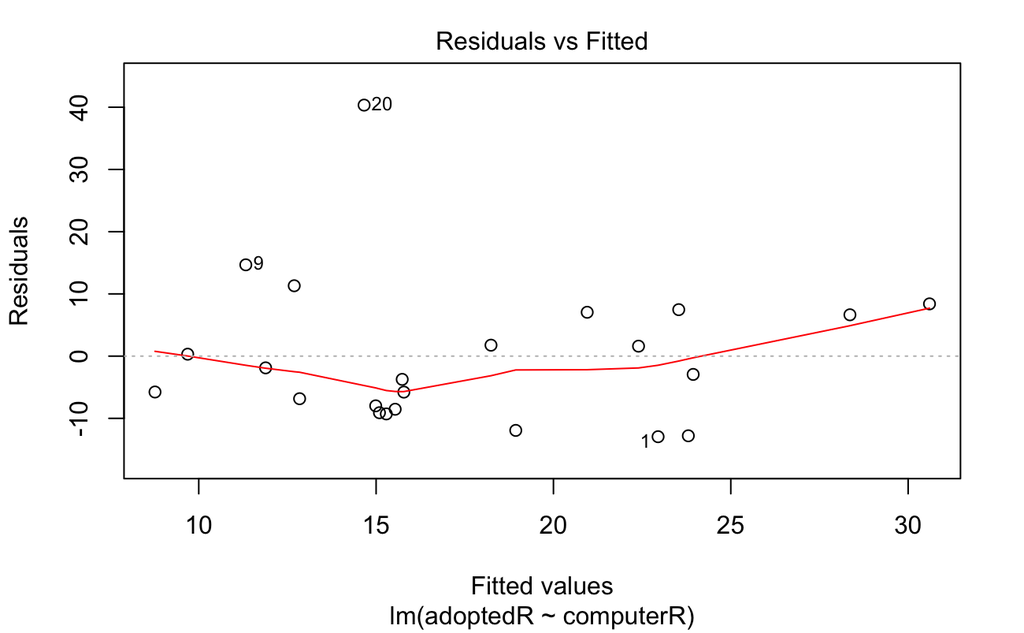

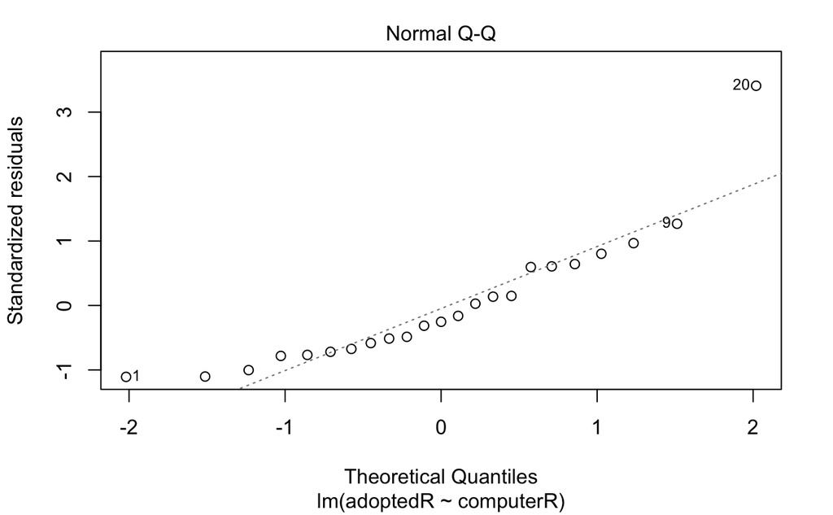

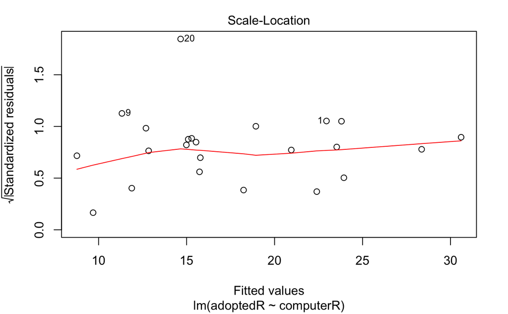

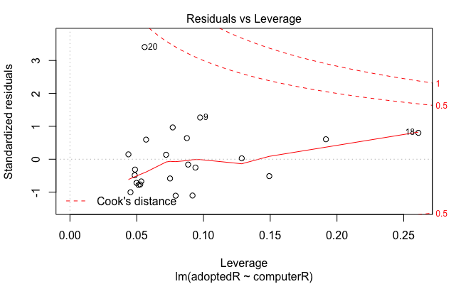

```r
plot(lm.model)
```

```r
resid <- lm.model$residuals
# using ggplot: https://rpubs.com/therimalaya/43190
# check normality
shapiro.test(resid)
```

```
    Shapiro-Wilk normality test

data:  resid
W = 0.84095, p-value = 0.001873
```

- Correlation matrix 選取解釋變數

```r
dogs1 <- dogs[-c(1,5)]
round(cor(dogs1),2); head(dogs1)
```

```
           captured adoptedR killedR population graduate farmArea divorced unemployed
captured       1.00    -0.17    0.26       0.90     0.75    -0.17     0.12      -0.12
adoptedR      -0.17     1.00   -0.80      -0.09     0.23     0.01     0.06      -0.24
killedR        0.26    -0.80    1.00       0.19    -0.18     0.02    -0.06       0.08
population     0.90    -0.09    0.19       1.00     0.83    -0.12     0.01      -0.08
graduate       0.75     0.23   -0.18       0.83     1.00    -0.26     0.08      -0.22
farmArea      -0.17     0.01    0.02      -0.12    -0.26     1.00    -0.71      -0.22
divorced       0.12     0.06   -0.06       0.01     0.08    -0.71     1.00       0.07
unemployed    -0.12    -0.24    0.08      -0.08    -0.22    -0.22     0.07       1.00
crimeR         0.33     0.43   -0.14       0.42     0.42    -0.39     0.24       0.00
oldR          -0.16    -0.54    0.58      -0.15    -0.43     0.70    -0.62      -0.01
computerR      0.36     0.44   -0.28       0.47     0.63    -0.34     0.08      -0.08
           crimeR  oldR computerR
captured     0.33 -0.16      0.36
adoptedR     0.43 -0.54      0.44
killedR     -0.14  0.58     -0.28
population   0.42 -0.15      0.47
graduate     0.42 -0.43      0.63
farmArea    -0.39  0.70     -0.34
divorced     0.24 -0.62      0.08
unemployed   0.00 -0.01     -0.08
crimeR       1.00 -0.43      0.63
oldR        -0.43  1.00     -0.63
computerR    0.63 -0.63      1.00
```

|  | captured | adoptedR | killedR | population | graduate | farmArea | divorced | unemployed | crimeR | oldR | computerR |
| --- | --- | --- | --- | --- | --- | --- | --- | --- | --- | --- | --- |
| 1 | 152508 | 10 | 79 | 3205041 | 93097 | 15.46 | 7.21 | 4.1 | 2263.96 | 8.74 | 100.21 |
| 2 | 27612 | 7 | 62 | 384277 | 7471 | 12.70 | 6.17 | 4.3 | 1542.17 | 13.19 | 71.43 |
| 3 | 56889 | 11 | 77 | 1572540 | 41987 | 30.66 | 7.20 | 4.3 | 1816.70 | 11.15 | 103.52 |
| 4 | 10389 | 21 | 69 | 401986 | 15328 | 20.46 | 5.98 | 4.0 | 2177.17 | 11.03 | 104.05 |
| 5 | 9358 | 12 | 69 | 464833 | 8220 | 18.66 | 5.68 | 4.2 | 1479.97 | 15.60 | 72.20 |
| 6 | 46222 | 7 | 88 | 1270622 | 22807 | 24.10 | 5.55 | 4.2 | 1785.23 | 13.95 | 84.63 |

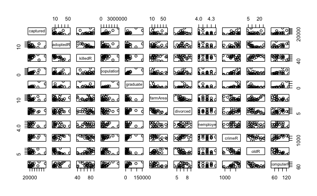

```r
pairs(dogs1)
```

```r
# or using ggplot2
```

[output not shown]

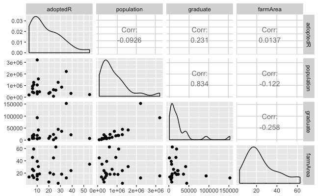

```r
#install.package('GGally')
require(GGally)
ggpairs(dogs1[, c(2, 4:6)])
```

# Week 10 Homework : 爬蟲程式自己來

### Web Crawler/Web Scraping DIY with R

- (indi.100pt) 小組先共同選擇一個來源（如報紙／人力網／租屋網／批踢踢等等），每個人抓取某部分內容做分析。例如：抓取蘋果日報的即時新聞標題，建立當日各主題的詞頻表。
- (group bonus.50pt) 把小組每個人做的部分兜起來說一個故事。

參考中文簡介

> - https://imdataman.github.io/how-to-make-data-news.html#/67
> - https://github.com/ywchiu/rcrawler
> - [jiebaR 中文分詞教程](https://jiebar.qinwf.com/)
> - [使用自定義用戶詞庫](https://github.com/qinwf/jiebaR/wiki/%E4%BD%BF%E7%94%A8%E8%87%AA%E5%AE%9A%E4%B9%89%E7%94%A8%E6%88%B7%E8%AF%8D%E5%BA%93)